# Formatieve_opdracht_1

Pedro de Bos, Thijmen van Brenk

31-3-2022

De onderzoeksvraag stelt: “Wat zijn de verschillen in genexpressie tussen iPSC en fibroblasten?”

Opstellen van een data-file om de SRR-identifiers op te slaan: doe handmatig! Gebaseerd op de SRR-identifiers die je als tsv in het bestand SRR_identifier.txt opslaat zal het programma automatisch all die fastq’s downloaden

**Downloaden van fastq**

```bash
for SRR in $(cat /home/1762403/temp_daur2/formatieve_opdracht1/SRR_identifier.txt)
do
  echo "fastq-dump --split-3 --outdir '/home/1762403/temp_daur2/formatieve_opdracht1' --gzip $SRR"
done
```

```
## fastq-dump --split-3 --outdir '/home/1762403/temp_daur2/formatieve_opdracht1' --gzip SRR7866687
## fastq-dump --split-3 --outdir '/home/1762403/temp_daur2/formatieve_opdracht1' --gzip SRR7866688
## fastq-dump --split-3 --outdir '/home/1762403/temp_daur2/formatieve_opdracht1' --gzip SRR7866689
## fastq-dump --split-3 --outdir '/home/1762403/temp_daur2/formatieve_opdracht1' --gzip SRR7866690
## fastq-dump --split-3 --outdir '/home/1762403/temp_daur2/formatieve_opdracht1' --gzip SRR7866691
## fastq-dump --split-3 --outdir '/home/1762403/temp_daur2/formatieve_opdracht1' --gzip SRR7866692
## fastq-dump --split-3 --outdir '/home/1762403/temp_daur2/formatieve_opdracht1' --gzip SRR7866693
## fastq-dump --split-3 --outdir '/home/1762403/temp_daur2/formatieve_opdracht1' --gzip SRR7866694
```

De data van de fastq files bevatten allen goede per base sequence quality en per sequence quality scores, dus we kunnen stellen dat de data bruikbaar is

**Index creeëren met subread package**

```r
#Eerst een index creeëren
hg38_ref<-"/home/daur2/rnaseq/hg38_genome/GRCh38.primary_assembly.genome.fa"
hg38_index<-"~/temp_daur2/formatieve_opdracht1/hg38_index/hg38_index"
buildindex(basename = hg38_index,
           reference = hg38_ref,
           gappedIndex = FALSE,
           indexSplit = FALSE)
```

**Alignment uitvoeren met subread package**

```r
#Directories klaarzetten
fastq_dir<-"/home/daur2/rnaseq/rnaseq_ipsc/fastq/"
hg38_index_2<-"/home/daur2/rnaseq/hg38_index/hg38_index" #Deze anders genoemd aangezien de directory in mijn map niet gevuld is. Als ik het voor het echie zou runnen zou dit wel hetzelfde zijn als hg38_index
bam_dir<-"~/temp_daur2/formatieve_opdracht1/bam_dir/bam_dir"
samples<-list.files(fastq_dir, pattern="_[12].fastq.gz") %>% str_remove(pattern="_[12].fastq.gz") %>% unique()

#Alignment uitvoeren
alignments_statistics_ipsc<-align(
  index=hg38_index_2,
  readfile1=paste0(fastq_dir,samples,"_1.fastq.gz"),
  readfile2=paste0(fastq_dir,samples,"_2.fastq.gz"),
  type="rna", input_format = "gzFASTQ", output_format = "BAM",
  output_file = paste0(bam_dir,samples,".bam"),

  unique = TRUE,

  nthreads = 10
)
saveRDS(alignments_statistics_ipsc, file=paste0(bam_dir,"alignment_statistics.rds"))
```

**alignment statistics grafiek**

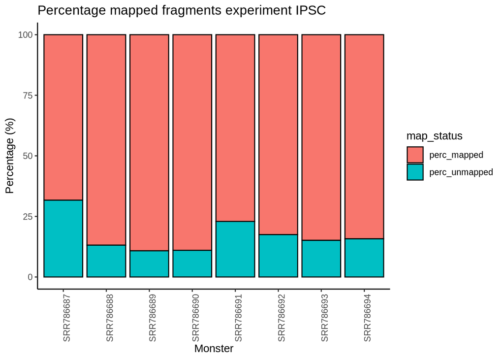

```r
#Data inlezen
alignment_statistics<-read_rds("/home/daur2/rnaseq/rnaseq_ipsc/bam/alignment_statistics.rds")
#Als tibble opslaan
alignment_statistics<-alignment_statistics %>% t() %>% as_tibble()
#Toevoegen van monster nummers
alignment_statistics<-alignment_statistics %>% mutate(monster=paste0("SRR",seq(786687,786694)))
#Volgorde veranderen
alignment_statistics<-alignment_statistics %>% dplyr::select(monster, Total_fragments:Indels )

#Summary maken
alignment_statistics_sum<-alignment_statistics %>% group_by(monster) %>% summarise(
  perc_mapped=Mapped_fragments/Total_fragments*100,
  perc_unmapped=100-perc_mapped
)
alignment_statistics_pivot<-alignment_statistics_sum %>% pivot_longer(cols=c(perc_mapped, perc_unmapped), names_to = "map_status", values_to = "percentage")

#GGplot maken
alignment_statistics_pivot %>% ggplot(aes(x=monster, y=percentage, fill=map_status))+
  geom_col(colour="black")+
  theme_classic()+
  labs(
    title="Percentage mapped fragments experiment IPSC",
    x="Monster",
    y="Percentage (%)"
  )+
  theme(axis.text.x=element_text(angle=90))
```

**Genereren count table**

```r
#Selecteren van pad naar directories voor code
bam_dir<-"/home/daur2/rnaseq/rnaseq_ipsc/bam/"
counts_dir<-"~/temp_daur2/formatieve_opdracht1/counts_dir/"
bam_files<-list.files(bam_dir, pattern=".bam$", full.names = TRUE)
#Echt genereren van een count table
featureCounts(
  files=bam_files,
  annot.inbuilt = "hg38",
  useMetaFeatures = TRUE,
  strandSpecific = 1,
  isPairedEnd = TRUE,
  nthreads = 10
)
#Reading the count directory (was already pre-generated, otherwise would be from counts_dir)
count_ipsc<-readRDS("/home/daur2/rnaseq/rnaseq_ipsc/counts/read_counts.rds")
count_matrix_ipsc<-count_ipsc$counts
```

**Making a graph from count table**

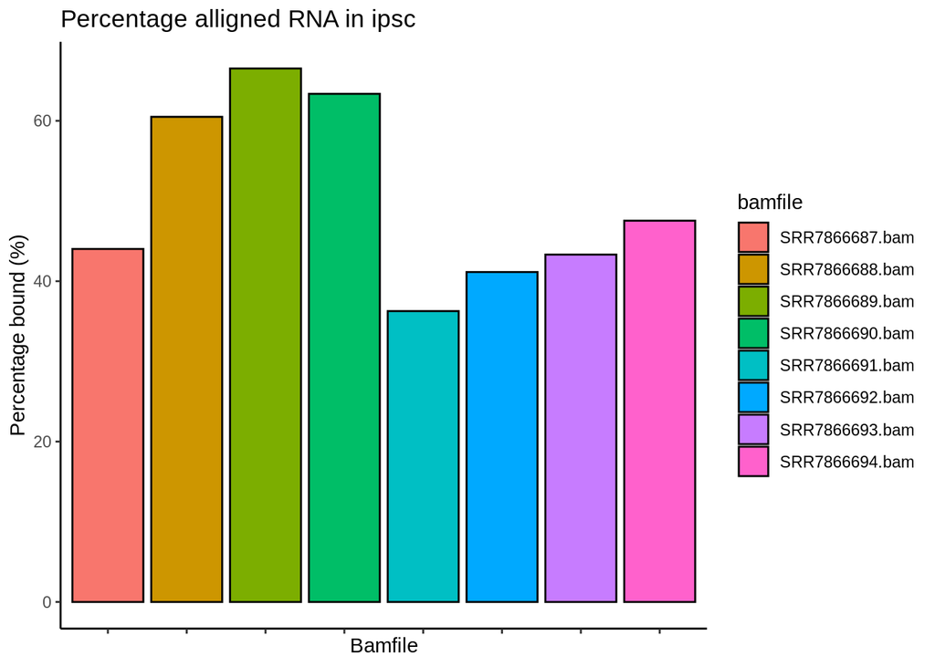

```r
count_ipsc<-readRDS("/home/daur2/rnaseq/rnaseq_ipsc/counts/read_counts.rds")
count_ipsc_stats<-count_ipsc$stat

rownames(count_ipsc_stats)<-count_ipsc_stats$Status
count_ipsc_stats$Status<-NULL

count_ipsc_stats_sum<-count_ipsc_stats %>% t() %>% as_tibble() %>%
  mutate(bamfile=colnames(count_ipsc_stats)) %>%
  mutate(total=colSums(count_ipsc_stats)) %>%
  mutate(perc_bound=Assigned/total*100) %>%
  dplyr::select(bamfile,total, perc_bound)

count_ipsc_stats_sum %>% ggplot(aes(x=bamfile, y=perc_bound, fill=bamfile))+
  geom_col(colour="black")+
  theme_classic()+
  theme(axis.text.x=element_blank())+
  labs(
    x="Bamfile",
    y="Percentage bound (%)",
    title="Percentage alligned RNA in ipsc"
  )
```

**Creating the DESeq2 object**

```r
#Obtaining count matrix
count_ipsc<-readRDS("/home/daur2/rnaseq/rnaseq_ipsc/counts/read_counts.rds")
count_matrix_ipsc<-count_ipsc$counts
colnames(count_matrix_ipsc)
```

```
## [1] "SRR7866687.bam" "SRR7866688.bam" "SRR7866689.bam" "SRR7866690.bam"
## [5] "SRR7866691.bam" "SRR7866692.bam" "SRR7866693.bam" "SRR7866694.bam"
```

```r
#Obtaining metadata
metadata_ipsc<-read_csv("/home/daur2/rnaseq/rnaseq_ipsc/ipsc_sampledata.csv")
metadata_ipsc<-as.data.frame(metadata_ipsc)
rownames(metadata_ipsc)<-paste0(metadata_ipsc$Run,".bam")

#Checking of row/colnames are the same
rownames(metadata_ipsc) == colnames(count_matrix_ipsc)
```

```
## [1] TRUE TRUE TRUE TRUE TRUE TRUE TRUE TRUE
```

```r
#Creating factor in metadata
metadata_ipsc$Cell_type
```

```
## [1] "Skin derived fibroblast" "Skin derived fibroblast"
## [3] "Skin derived fibroblast" "Skin derived fibroblast"
## [5] "iPSC"                    "iPSC"
## [7] "iPSC"                    "iPSC"
```

```r
is.factor(metadata_ipsc$Cell_type)
```

```
## [1] FALSE
```

```r
metadata_ipsc$Cell_type<-metadata_ipsc$Cell_type %>% str_replace("Skin derived fibroblast", "skin_derived_fibroblast")
metadata_ipsc$Cell_type<-metadata_ipsc$Cell_type %>% factor(levels=c("skin_derived_fibroblast", "iPSC"))
is.factor(metadata_ipsc$Cell_type)
```

```
## [1] TRUE
```

```r
#Finally, creating the library
dds_ipsc<-DESeqDataSetFromMatrix(
  countData = count_matrix_ipsc,
  colData = metadata_ipsc,
  design = ~Cell_type
)
#And normalising it
dds_ipsc_normalised<-rlog(dds_ipsc)
```

**Making a principal component analysis**

```r
pca_ipsc<-dds_ipsc_normalised %>% assay() %>% t() %>% prcomp()
pca_summary<-summary(pca_ipsc)$importance
pca_ipsc$x
```

```
##                      PC1        PC2        PC3        PC4        PC5       PC6
## SRR7866687.bam -128.8666 -52.730982   6.875558 -18.115609   8.986563  18.28230
## SRR7866688.bam -133.2055 -52.547845  10.749986  18.444492  -8.052174 -19.10413
## SRR7866689.bam -133.5885  53.164898  -8.885141   1.876829  35.647386 -14.07830
## SRR7866690.bam -136.6027  50.502745  -8.678611  -2.532327 -36.182984  14.63417
## SRR7866691.bam  131.9699 -12.118945 -42.817982 -19.455006   8.648069  19.10213
## SRR7866692.bam  134.7830  -8.899808 -41.264594  19.474806  -9.665320 -21.28137
## SRR7866693.bam  133.8044  11.667815  43.805120 -33.644986  -7.223195 -21.45229
## SRR7866694.bam  131.7061  10.962123  40.215664  33.951802   7.841656  23.89748
##                         PC7           PC8
## SRR7866687.bam -24.69145071 -1.228546e-12
## SRR7866688.bam  23.61285117 -7.188013e-13
## SRR7866689.bam   0.24638556 -6.202196e-13
## SRR7866690.bam   0.19134000 -1.626171e-12
## SRR7866691.bam  22.93710922  2.115078e-12
## SRR7866692.bam -22.07410874  1.571825e-12
## SRR7866693.bam  -0.01281953  7.637822e-13
## SRR7866694.bam  -0.20930697 -2.029546e-13
```

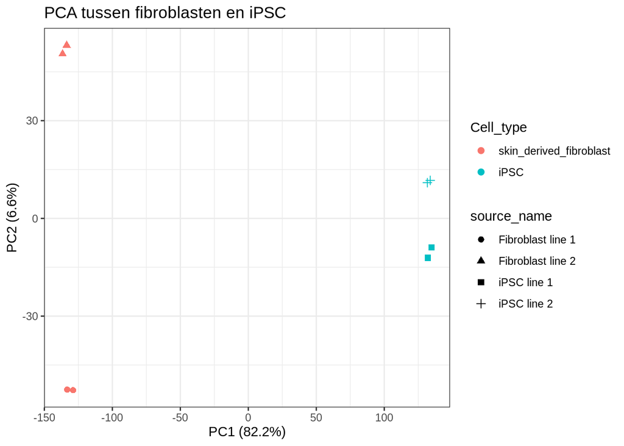

```r
#plotting klaarzetten
pca_ipsc_plotting<-cbind(metadata_ipsc,pca_ipsc$x)
#Variabelen 1 en 2 klaarzetten
PCA_1<-round(pca_summary["Proportion of Variance","PC1"]*100,digits=1)
PCA_2<-round(pca_summary["Proportion of Variance","PC2"]*100,digits=1)
#In een ggplot
pca_ipsc_plotting %>% ggplot()+
  geom_point(aes(x=PC1, y=PC2, colour=Cell_type, shape=source_name), size=2)+
  labs(
    x=paste0("PC1 (",PCA_1,"%)"),
    y=paste0("PC2 (",PCA_2,"%)"),
    title="PCA tussen fibroblasten en iPSC"
  )+
  theme_bw()
```

Conclusie gebaseerd op de PCA: Er is een erg groot verschil gebasserd op principal component 1 tussen iPSC en Skin derived fibroblasten. Verder vormen de de iPSC’s en fibroblasten onder zich ook 2 groepen gebaseerd op principal component 2, echter deze is relatief veel kleiner, en als je naar de vormen kijkt is duidelijk te zien dat deze te maken hebben met de type gebruikte cel-lijn

**Maken van een heatmap**

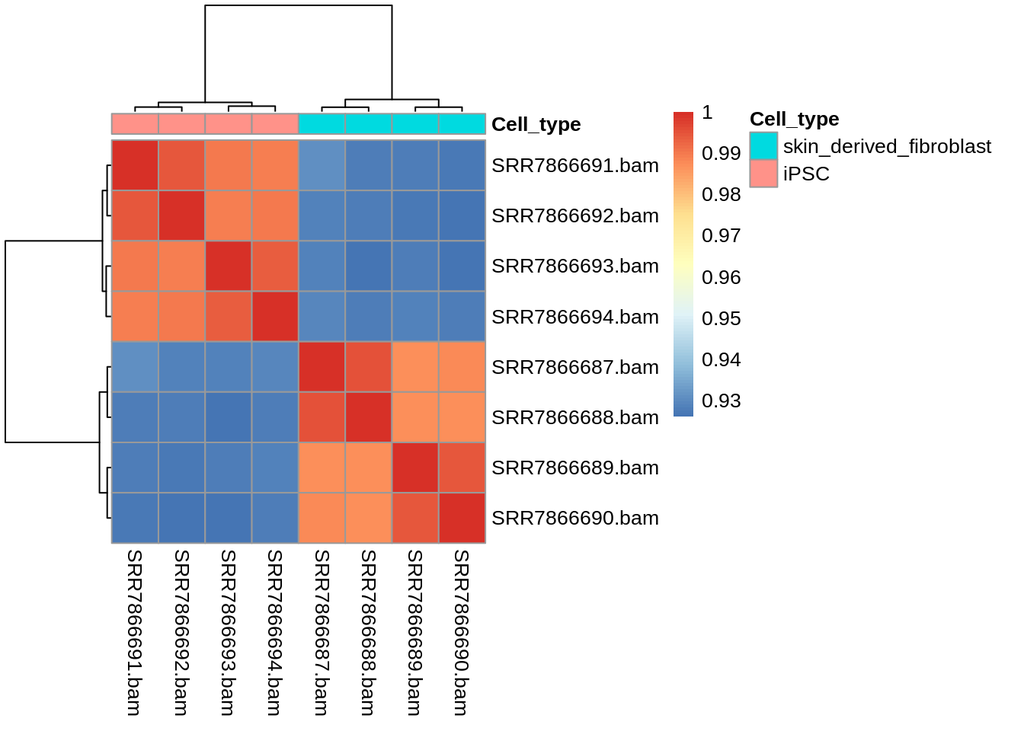

```r
#Opstellen Matrix
dds_ipsc_normalised_matrix<-assay(dds_ipsc_normalised)
#Correlatie bepalen, daarna correlatie in pheatmap stoppen
ipsc_cor<-cor(dds_ipsc_normalised_matrix)
pheatmap(ipsc_cor, annotation = metadata_ipsc["Cell_type"])
```

Gebaseerd op de heatmap is nogmaals overduidelijk te zien dat de genexpressie van skin derived fibroblasts en iPSC’s erg verschillen.

**Les 3**

**DGE analyse**

```r
ipsc_dge<-DESeq(dds_ipsc)
ipsc_results<-results(ipsc_dge, alpha=0.05, lfcThreshold = 1)
summary(ipsc_results)
```

```
##
## out of 23095 with nonzero total read count
## adjusted p-value < 0.05
## LFC > 1.00 (up)    : 3222, 14%
## LFC < -1.00 (down) : 2510, 11%
## outliers [1]       : 3, 0.013%
## low counts [2]     : 4424, 19%
## (mean count < 1)
## [1] see 'cooksCutoff' argument of ?results
## [2] see 'independentFiltering' argument of ?results
```

LFC > 1 = 3222 (14%)

LFC < -1 = 2510 (11%)

in vergelijking met de luchtweg studie:

LFC > 1 = 68 (0.32%)

LFC < 1 = 36 (0.17%)

Er is veeeeel meer significant verschil dan bij de luchtwegen

**Volcano plot**

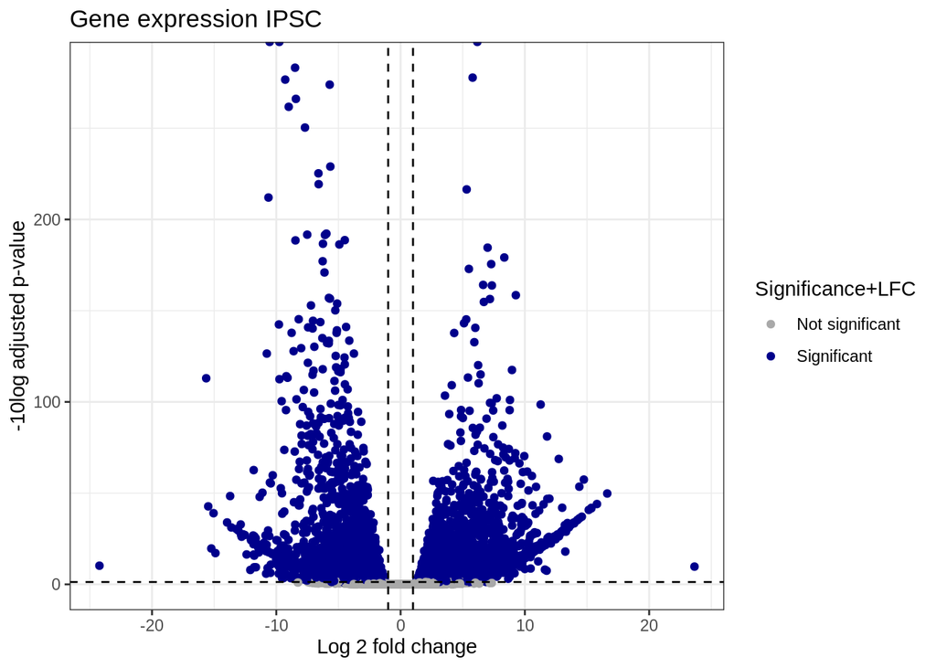

```r
#Maken van een data frame van de data, en NA's eruit filteren
ipsc_results_volcano<-data.frame(ipsc_results) %>% filter(!is.na(padj))

#Factoren toevoegen voor padj>0.05 en LFC>1. Via abs() kijkt hij gelijk naar zowel positieve als negatieve
ipsc_results_volcano_2<-ipsc_results_volcano %>% mutate(
  significance=if_else(padj<0.05,"significant","not significant"),
  log2foldchange=if_else(abs(log2FoldChange)>1,"L2FC>1","L2FC<1"),
  signif_LFC=if_else(padj<0.05 & abs(log2FoldChange)>1,"Significant","Not significant")
)

ipsc_results_volcano_2 %>% ggplot(aes(x=log2FoldChange,y=-log10(padj),colour=signif_LFC))+
  geom_point()+
  labs(
    title="Gene expression IPSC",
    x="Log 2 fold change",
    y="-10log adjusted p-value"
  )+
  geom_vline(xintercept = 1, linetype="dashed")+
  geom_vline(xintercept = -1, linetype="dashed")+
  geom_hline(yintercept = -log10(0.05), linetype="dashed")+
  scale_colour_manual(values=c("darkgrey", "darkblue"), name="Significance+LFC")+
  theme_bw()
```

**Heatmap maken**

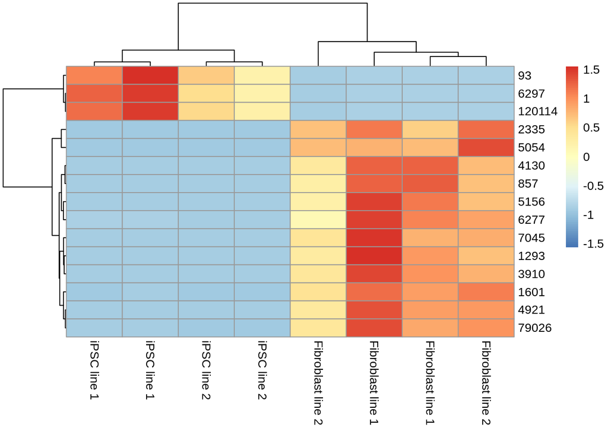

```r
top_15_ipsc_names<-rownames(ipsc_results[order(ipsc_results$padj)[1:15],])
count_values_ipsc<-assay(dds_ipsc)[top_15_ipsc_names,]
colnames(count_values_ipsc)<-colData(dds_ipsc)$source_name
pheatmap(count_values_ipsc, show_rownames = TRUE, scale="row")
```

**Les 4**

**Heatmap met gen-namen maken**

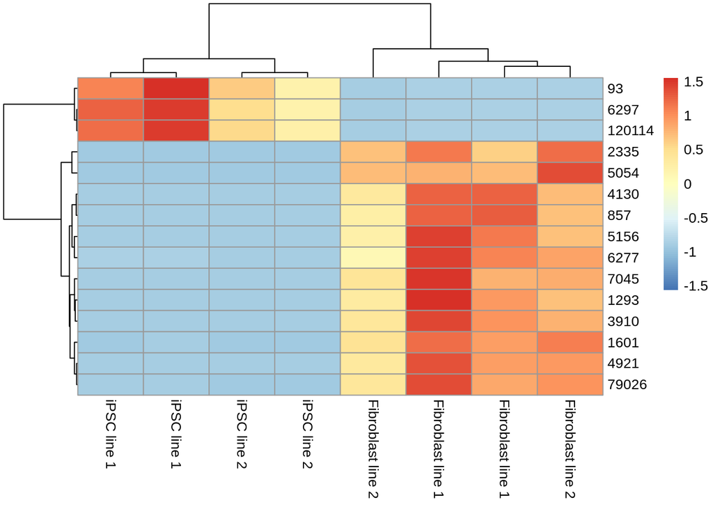

```r
#Code voor pheatmap
top_15_ipsc_names<-rownames(ipsc_results[order(ipsc_results$padj)[1:15],])
count_values_ipsc<-assay(dds_ipsc)[top_15_ipsc_names,]
colnames(count_values_ipsc)<-colData(dds_ipsc)$source_name
pheatmap(count_values_ipsc, show_rownames = TRUE, scale="row")
```

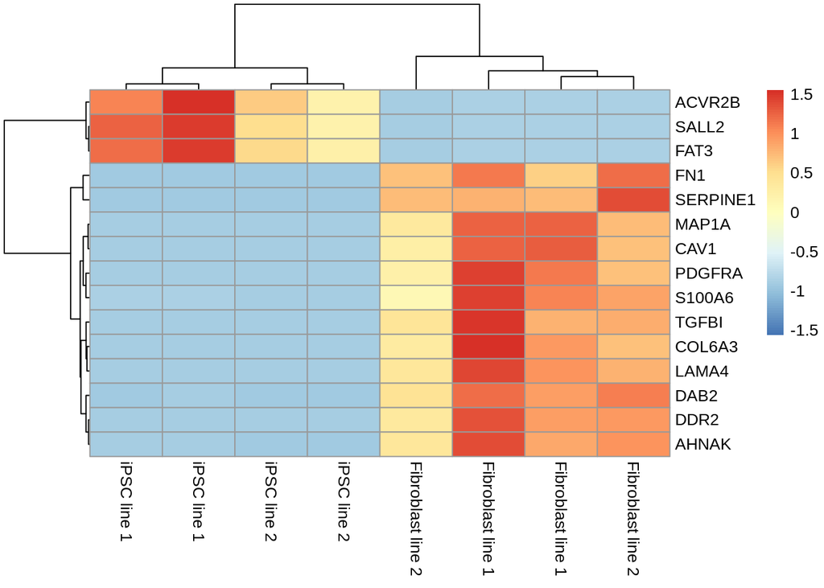

```r
#Gen-symbolen tevoorschijn toveren
#Eerst de Entrez-waardes opslaan als data frame
top_15_ipsc_genidentifiers<-rownames(count_values_ipsc)
top_15_ipsc_genidentifiers<-top_15_ipsc_genidentifiers %>% data.frame()
#Met map-IDS de symbols krijgen
top_15_symbols<-mapIds(org.Hs.eg.db,
       keys = top_15_ipsc_genidentifiers$.,
       column = "SYMBOL",
       keytype = "ENTREZID",
       multiVals = "first") %>% data.frame()
rownames(count_values_ipsc)<-top_15_symbols$.

#Nogmaals heatmap maken
pheatmap(count_values_ipsc, show_rownames = TRUE, scale="row")
```

_Top 20 upregulated genes__

```r
#upregulated genen opslaan
ipsc_gene_upregulated<-ipsc_results %>% data.frame() %>% filter(log2FoldChange > 1, padj < 0.01) %>% rownames()

#ALLE genen opslaan
ipsc_gene_total<-ipsc_results %>% data.frame() %>% rownames()

#Data als object voor analyse opslaan
ipsc_testobject_upregulated<-new("GOHyperGParams",
                 geneIds=ipsc_gene_upregulated,
                 universeGeneIds=ipsc_gene_total,
                 annotation="org.Hs.eg.db",
                 ontology="BP",
                 pvalueCutoff=1,
                 testDirection="over"
)

#Analyse uitvoeren
ipsc_gotermanalysis_upregulated<-hyperGTest(ipsc_testobject_upregulated)

#Resultaten opslaan als summary
ipsc_goterm_sum_upregulated<-summary(ipsc_gotermanalysis_upregulated)

#Adjusted P-value toevoegen
ipsc_goterm_sum_upregulated$padj<-p.adjust(ipsc_goterm_sum_upregulated$Pvalue, method = "BH")

#Filteren genen kleiner dan 5, groter dan 500
ipsc_goterm_sum_upregulated<-ipsc_goterm_sum_upregulated %>% filter(Count>5 & Count<500)

#Selecteren van top 20 genen
ipsc_goterm_sum_upregulated_top20<-ipsc_goterm_sum_upregulated[order(ipsc_goterm_sum_upregulated$padj)[1:20],]

#Factor maken van "Term" en daarop sorteren
ipsc_goterm_sum_upregulated_top20$Term<-factor(
  ipsc_goterm_sum_upregulated_top20$Term,
  levels=ipsc_goterm_sum_upregulated_top20$Term[order(ipsc_goterm_sum_upregulated_top20$padj, decreasing = TRUE)]
)
is.factor(ipsc_goterm_sum_upregulated_top20$Term)
```

```
## [1] TRUE
```

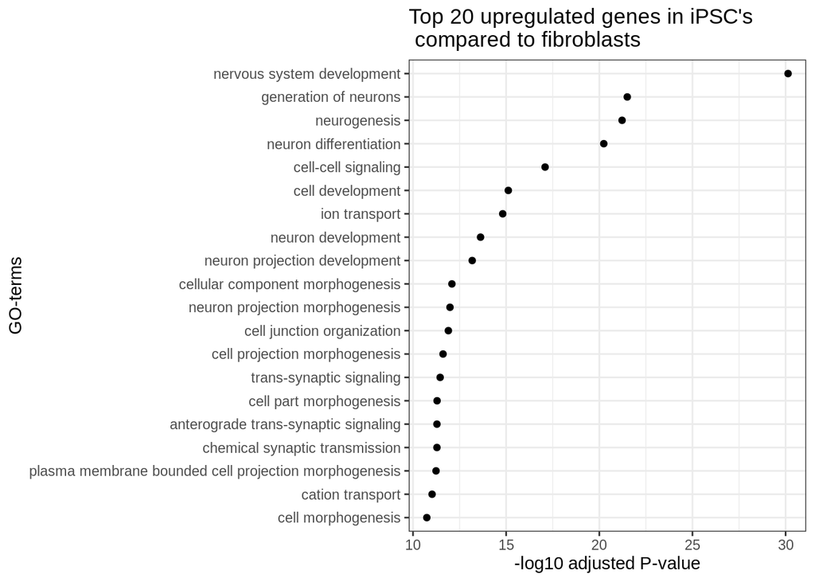

```r
#Plotten
ipsc_goterm_sum_upregulated_top20 %>% ggplot(aes(x=Term, y=-log10(padj)))+
  geom_point()+
  coord_flip()+
  labs(
    title="Top 20 upregulated genes in iPSC's \n compared to fibroblasts",
    y="-log10 adjusted P-value",
    x="GO-terms"
  )+
  theme_bw()
```

**Top 20 downregulated genes**

```r
#downregulated genen opslaan
ipsc_gene_downregulated<-ipsc_results %>% data.frame() %>% filter(log2FoldChange < -1, padj < 0.01) %>% rownames()

#ALLE genen opslaan
ipsc_gene_total<-ipsc_results %>% data.frame() %>% rownames()

#Data als object voor analyse opslaan
ipsc_testobject_downregulated<-new("GOHyperGParams",
                                 geneIds=ipsc_gene_downregulated,
                                 universeGeneIds=ipsc_gene_total,
                                 annotation="org.Hs.eg.db",
                                 ontology="BP",
                                 pvalueCutoff=1,
                                 testDirection="over"
)

#Analyse uitvoeren
ipsc_gotermanalysis_downregulated<-hyperGTest(ipsc_testobject_downregulated)

#Resultaten opslaan als summary
ipsc_goterm_sum_downregulated<-summary(ipsc_gotermanalysis_downregulated)

#Adjusted P-value toevoegen
ipsc_goterm_sum_downregulated$padj<-p.adjust(ipsc_goterm_sum_downregulated$Pvalue, method = "BH")

#Filteren genen kleiner dan 5, groter dan 500
ipsc_goterm_sum_downregulated<-ipsc_goterm_sum_downregulated %>% filter(Count>5 & Count<500)

#Selecteren van top 20 genen
ipsc_goterm_sum_downregulated_top20<-ipsc_goterm_sum_downregulated[order(ipsc_goterm_sum_downregulated$padj)[1:20],]

#Factor maken van "Term" en daarop sorteren
ipsc_goterm_sum_downregulated_top20$Term<-factor(
  ipsc_goterm_sum_downregulated_top20$Term,
  levels=ipsc_goterm_sum_downregulated_top20$Term[order(ipsc_goterm_sum_downregulated_top20$padj, decreasing = TRUE)]
)
is.factor(ipsc_goterm_sum_downregulated_top20$Term)
```

```
## [1] TRUE
```

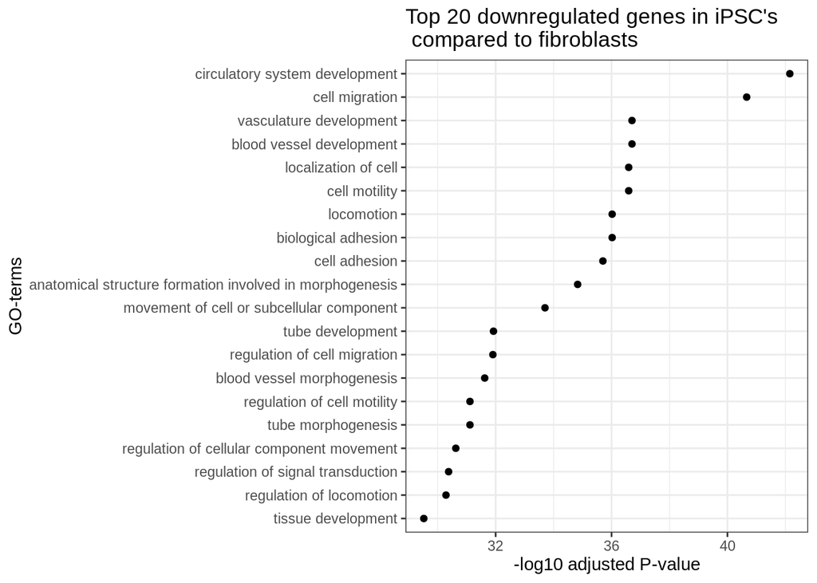

```r
#Plotten
ipsc_goterm_sum_downregulated_top20 %>% ggplot(aes(x=Term, y=-log10(padj)))+
  geom_point()+
  coord_flip()+
  labs(
    title="Top 20 downregulated genes in iPSC's \n compared to fibroblasts",
    y="-log10 adjusted P-value",
    x="GO-terms"
  )+
  theme_bw()
```

**Opstellen van functie om automatisch summaries te maken**

```r
DESeqEnrich<-function(DESeq2_results,regulated,LFC,p_val){
  #Controleren of input TRUE (upregulated) of FALSE (downregulated) is en gebaseerd hierop goed op de LFC filteren
  gene_regulated<-DESeq2_results %>% data.frame()
  if(regulated){
    gene_regulated<-gene_regulated %>% filter(log2FoldChange > LFC, padj < p_val)
  }
  else{
    gene_regulated<-gene_regulated %>% filter(log2FoldChange < -LFC, padj < p_val)
  }
  gene_regulated<-gene_regulated %>% rownames()

  #Totale hoeveelheid genen opslaan
  gene_total<-DESeq2_results %>% data.frame() %>% rownames()

  #Data als object voor analyse opslaan
  testobject<-new("GOHyperGParams",
                                   geneIds=gene_regulated,
                                   universeGeneIds=gene_total,
                                   annotation="org.Hs.eg.db",
                                   ontology="BP",
                                   pvalueCutoff=1,
                                   testDirection="over"
  )
  #Analyse uitvoeren
  gotermanalysis<-hyperGTest(testobject)

  #Summary verkrijgen
  summary(gotermanalysis)

}
#Controle: Deze twee zouden hetzelfde moeten zijn
summary(ipsc_gotermanalysis_upregulated) %>% head()
```

```
##       GOBPID       Pvalue OddsRatio ExpCount Count Size
## 1 GO:0007399 7.703565e-35  2.074011 293.0077   489 2414
## 2 GO:0007275 2.366113e-26  1.662167 623.3999   839 5136
## 3 GO:0048699 9.885855e-26  2.108729 183.6456   321 1513
## 4 GO:0048856 2.137575e-25  1.628083 694.0422   911 5718
## 5 GO:0022008 3.125256e-25  2.051394 197.9683   338 1631
## 6 GO:0032501 1.223834e-24  1.588507 911.1883  1135 7507
##                                 Term
## 1         nervous system development
## 2 multicellular organism development
## 3              generation of neurons
## 4   anatomical structure development
## 5                       neurogenesis
## 6   multicellular organismal process
```

```r
DESeqEnrich(ipsc_results,TRUE,1,0.01) %>% head()
```

```
##       GOBPID       Pvalue OddsRatio ExpCount Count Size
## 1 GO:0007399 7.703565e-35  2.074011 293.0077   489 2414
## 2 GO:0007275 2.366113e-26  1.662167 623.3999   839 5136
## 3 GO:0048699 9.885855e-26  2.108729 183.6456   321 1513
## 4 GO:0048856 2.137575e-25  1.628083 694.0422   911 5718
## 5 GO:0022008 3.125256e-25  2.051394 197.9683   338 1631
## 6 GO:0032501 1.223834e-24  1.588507 911.1883  1135 7507
##                                 Term
## 1         nervous system development
## 2 multicellular organism development
## 3              generation of neurons
## 4   anatomical structure development
## 5                       neurogenesis
## 6   multicellular organismal process
```